# Tutorial 1

### Signal Training Data Generation

##### Produced by Group 3

**Introduction**

Welcome to tutorial 1! Here we will discuss the first part of three part series for creating a signal classification neural network. The goal of these tuturoials is to walk the user through all the stages of creating a neural network capable of identifying the underlying communication modulation type and signal metrics.

Tutorial 1 focuses on generating training data utilizing the Python library modem provided by [our stakeholder]. The training data is generated automatically through the code produced below. In this tutorial we'll explain each portion of the code and remark on what each function achieves, why it is being used, and the greater context for signal generation and classification.

To begin we will outline that python libraries used in this tutorial. We'll briefly explain their function and significance.

**Imports**

**import sys:** Allows Python to manipulate different parts of the its runtime interpreter.

**numpy as np:** Allows Python to utilize a diverse collection of functions and data structures used for advanced math.

```python
###########
# IMPORTS #
###########
#
import sys
sys.path.append("../")
import numpy as np
import src.modems as modems
import matplotlib.pyplot as plt
import src.channels as channels
from scipy.stats import norm
from scipy.special import erfc
```

**Utility Functions**

The following section of functions below are a collection of functions that contain trivial code to generate the plots above. These are not important or novel, however the code is reproduced below for the benefit of the reader.

```python
#############
# FUNCTIONS #
#############
#
# Basic plot function
def plotSignal(signal):

    # Initialize figure
    plt.figure(figsize=(5.0, 5.0))
    plt.title('Symbol Constellation Plot', fontsize=20)
    plt.xlabel('In-Phase Symbol Component')
    plt.ylabel('Quadrature Symbol Component')

    # Set figure limits
    plt.xlim([-2.0, 2.0])
    plt.ylim([-2.0, 2.0])

    # Set grids for plot
    plt.grid();

    # Plot parts of the signal on the figure
    for i,x in enumerate(signal.symb_table):
        plt.annotate(format(i, '01b'), xy=[x.real, x.imag], xytext=[-15.0, -15.0], textcoords='offset points')
        plt.plot(x.real, x.imag, '*')

    plt.show()

def plotCosinePulsesReal(pulses, samples, totalSamples):

    # Initialize figure
    plt.figure(figsize=(5.0, 5.0))
    plt.title('In-Phase Component of Generated Raised Cosine Signal', fontsize=20)
    plt.ylabel('Amplitude')
    plt.xlabel('Sample Number')

    # Set figure limits
    plt.ylim([-1.0, 1.0])

    # Set grids for plot
    plt.grid();

    # Plot real portions of raised cosine pulses
    plt.plot(pulses.real, '-*')
    plt.stem(np.arange(samples,(totalSamples+1)*samples,samples), pulses[samples:(totalSamples+1)*samples:samples].real, linefmt='--r', markerfmt='ro')

    plt.show()

def plotCosinePulsesImaginary(pulses, samples, totalSamples):

    # Initialize figure
    plt.figure(figsize=(5.0, 5.0))
    plt.title('Quadrature Component of Generated Raised Cosine Signal', fontsize=20)
    plt.ylabel('Amplitude')
    plt.xlabel('Sample Number')

    # Set figure limits
    plt.ylim([-1.0, 1.0])

    # Set grids for plot
    plt.grid();

    # Plot real portions of raised cosine pulses
    plt.plot(pulses.imag, '-*')
    plt.stem(np.arange(samples,(totalSamples+1)*samples,samples), pulses[samples:(totalSamples+1)*samples:samples].real, linefmt='--r', markerfmt='ro')

    plt.show()

def plotCarrierModulationReal(modulated, samples, totalSamples):

    # Initialize figure
    plt.figure(figsize=(5.0, 5.0))
    plt.title('In-Phase Component of Carrier Modulated Signal', fontsize=20)
    plt.ylabel('Amplitude')
    plt.xlabel('Sample Number')

    # Set figure limits
    plt.ylim([-1.0, 1.0])

    # Set grids for plot
    plt.grid();

    plotAmount = totalSamples * samples
    plt.plot(modulated[0:plotAmount].real, '-*')
    plt.show()

def plotCarrierModulationImaginary(modulated, samples, totalSamples):

    # Initialize figure
    plt.figure(figsize=(5.0, 5.0))
    plt.title('Quadrature Component of Carrier Modulated Signal', fontsize=20)
    plt.ylabel('Amplitude')
    plt.xlabel('Sample Number')

    # Set figure limits
    plt.ylim([-1.0, 1.0])

    # Set grids for plot
    plt.grid();

    plotAmount = totalSamples * samples
    plt.plot(modulated[0:plotAmount].imag, '-*')
    plt.show()

def plotCosinePulsesReal(pulses, samples, totalSamples):

    # Initialize figure
    plt.figure(figsize=(5.0, 5.0))
    plt.title('In-Phase Component of Generated Raised Cosine Signal', fontsize=20)
    plt.ylabel('Amplitude')
    plt.xlabel('Sample Number')

    # Set figure limits
    plt.ylim([-1.0, 1.0])

    # Set grids for plot
    plt.grid();

    # Plot real portions of raised cosine pulses
    plt.plot(pulses.real, '-*')
    plt.stem(np.arange(samples,(totalSamples+1)*samples,samples), pulses[samples:(totalSamples+1)*samples:samples].real, linefmt='--r', markerfmt='ro')

    plt.show()

def plotCosinePulsesImaginary(pulses, samples, totalSamples):

    # Initialize figure
    plt.figure(figsize=(5.0, 5.0))
    plt.title('Quadrature Component of Generated Raised Cosine Signal', fontsize=20)
    plt.ylabel('Amplitude')
    plt.xlabel('Sample Number')

    # Set figure limits
    plt.ylim([-1.0, 1.0])

    # Set grids for plot
    plt.grid();

    # Plot real portions of raised cosine pulses
    plt.plot(pulses.imag, '-*')
    plt.stem(np.arange(samples,(totalSamples+1)*samples,samples), pulses[samples:(totalSamples+1)*samples:samples].real, linefmt='--r', markerfmt='ro')

    plt.show()

def plotFourierTransform(pulses):

    # Variables
    fs = 1.0
    nfft = 256

    plt.psd(pulses, NFFT=nfft, Fs=fs, label='Power Spectral Density')

    plt.show()

def plotCarrierModulationReal(modulated, samples, totalSamples):

    # Initialize figure
    plt.figure(figsize=(5.0, 5.0))
    plt.title('In-Phase Component of Carrier Modulated Signal', fontsize=20)
    plt.ylabel('Amplitude')
    plt.xlabel('Sample Number')

    # Set figure limits
    plt.ylim([-1.0, 1.0])

    # Set grids for plot
    plt.grid();

    plotAmount = totalSamples * samples
    plt.plot(modulated[0:plotAmount].real, '-*')
    plt.show()

def plotCarrierModulationImaginary(modulated, samples, totalSamples):

    # Initialize figure
    plt.figure(figsize=(5.0, 5.0))
    plt.title('Quadrature Component of Carrier Modulated Signal', fontsize=20)
    plt.ylabel('Amplitude')
    plt.xlabel('Sample Number')

    # Set figure limits
    plt.ylim([-1.0, 1.0])

    # Set grids for plot
    plt.grid();

    plotAmount = totalSamples * samples
    plt.plot(modulated[0:plotAmount].imag, '-*')
    plt.show()

def plotDemodulate(receiver, original):

    # Initialize plot
    plt.title('Symbol Constellation Plot')
    plt.xlabel('In-Phase Symbol Component')
    plt.ylabel('Quadrature Symbol Component')
    plt.grid()

    # Limits on plot
    plt.xlim([-2.0, 2.0])
    plt.ylim([-2.0, 2.0])

    # Plot
    plt.plot(receiver.real, receiver.imag, 'b*')
    plt.plot(original.symb_table.real, original.symb_table.imag, 'r*')
    plt.show()
```

**Amplitude Shift Keying (ASK)**

Amplitude shift keying is a form of signal modulation that encodes digital data as variations of the amplitude of a carrier wave. No changes are made to phase as information is encoded. This is type of modulation is one of the most basic forms of information encoding for an RF signal.

Amplitude can be modulated in various "orders." The number of the order represents the amount of symbols that can be encoded in a single period of an encoded signal. This means a signal with amplitude modulation with an order of 8 can encode 8 unique symbols in a single period. These symbols are a unique string of bits (e.g. 000, 001, 010, 011, ...)

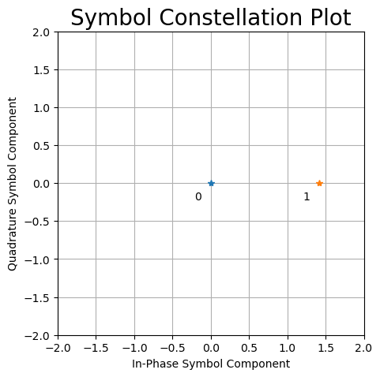

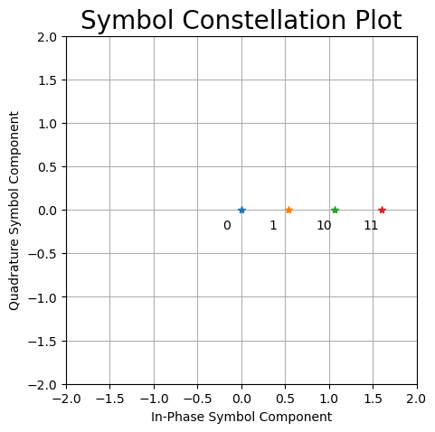

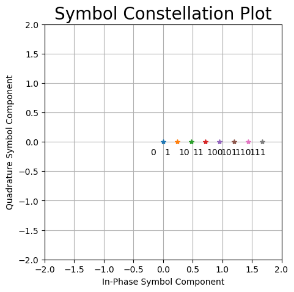

```python
################################
# AMPLITUDE SHIFT KEYING (ASK) #
################################
#
ask_2 = modems.ldapm(mod_type='ask', mod_order=2)
ask_4 = modems.ldapm(mod_type='ask', mod_order=4)
ask_8 = modems.ldapm(mod_type='ask', mod_order=8)

plotSignal(ask_2)
plotSignal(ask_4)
plotSignal(ask_8)
```

**Phase Shift Keying (PSK)**

Phase shift keying is a form of signal modulation that encodes digital data as variations of the phase of a carrier wave. No changes are made to amplitude as information is encoded. Phase modulation, in contrast to amplitude modulation, is more immune to noise and often produces high quality results at the receiver.

Similar to amplitude modulation, phase modulation can be modulated in various "orders." The number of the order represents the amount of symbols that can be encoded in a single period of an encoded signal.

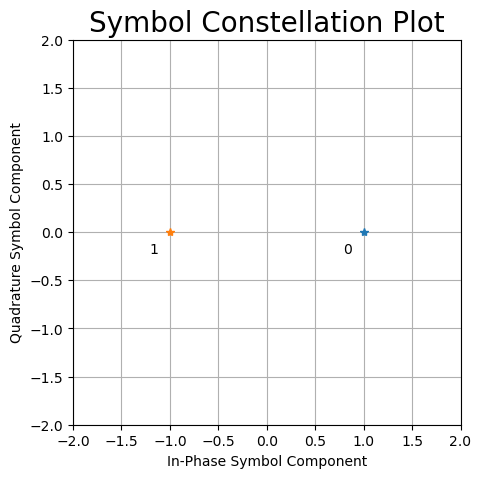

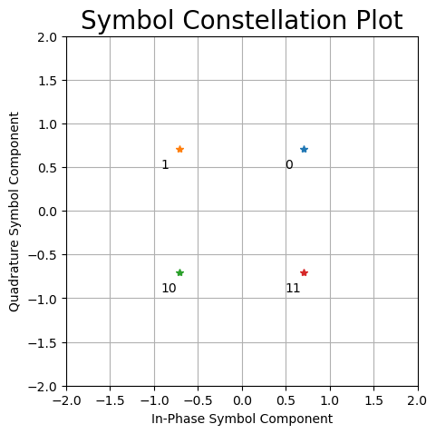

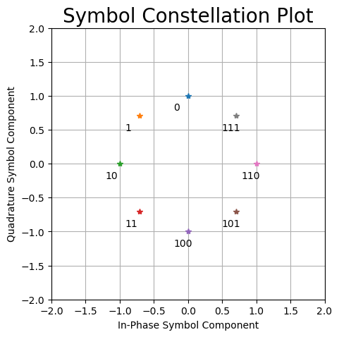

```python
############################
# PHASE SHIFT KEYING (PSK) #
############################
#
psk_2 = modems.ldapm(mod_type='psk', mod_order=2)
psk_4 = modems.ldapm(mod_type='psk', mod_order=4)
psk_8 = modems.ldapm(mod_type='psk', mod_order=8)

plotSignal(psk_2)
plotSignal(psk_4)
plotSignal(psk_8)
```

**Quadrature Amplitude Modulation (QAM)**

Quadrature amplitude modulation is a form of signal modulation that encodes digital data as variations of the amplitude and phase of a carrier wave. Quadrature amplitude modulation encodes the information into the amplitude of two seperate carrier waves. It then shifts the phase of one of those waves by 90 degrees. The two waves are then added together. Due to the variation of phase and amplitude the amount of information encoded is far more than amplitude or phase modulation alone.

Similar to both amplitude modulation and phase modulation, quadrature amplitude modulation can be modulated in various "orders." The number of the order represents the amount of symbols that can be encoded in a single period of an encoded signal.

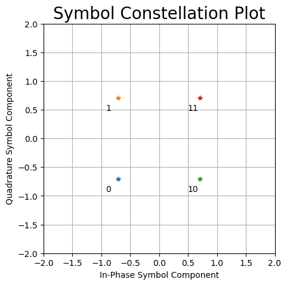

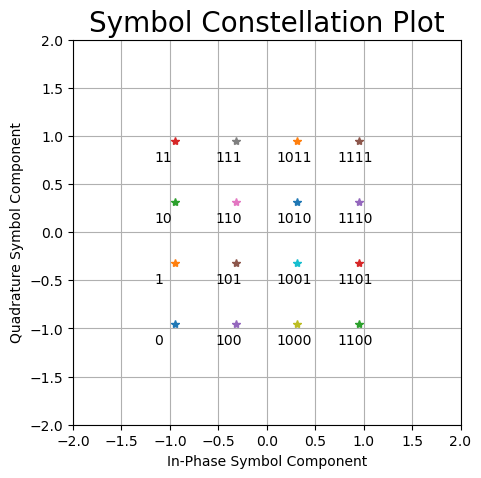

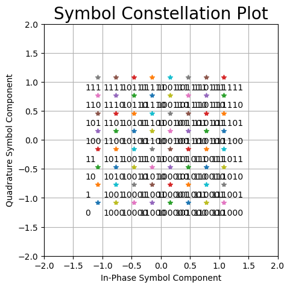

```python
###################################
# QUADRATURE AMPLITUDE MODULATION #
###################################
#
qam_8  = modems.ldapm(mod_type='qam', mod_order=8)
qam_16 = modems.ldapm(mod_type='qam', mod_order=16)
qam_64 = modems.ldapm(mod_type='qam', mod_order=64)

plotSignal(qam_8)
plotSignal(qam_16)
plotSignal(qam_64)
```

**Modulation and Encoding**

The below function *modems.ldapm* generates the signal data structure as shown above. This defines the type of modulation and the order that is being used. Thereafter a built in function that's part of the signal's data structure *gen_symbs(x)* generates a random string of symbols that is of size *x*. This is equivalent to a random series of bits.

Thereafter the random series of symbols is encoded into an equivalent cosine signal by utilizing the *get_samps(randomSymbols)* function. This function automatically generates a cosine wave that is the sum of two modulated amplitude signals. This function would perform a similarly if amplitude modulation or phase modulation were selected. In this example only 10 symbols are encoded and as such the resultant cosine signal remains small. However, this can be extended to a signal with a surplus of symbols if the variable **x** is changed.

In order to see how the cosine signal distributes energy over the set of frequencies a fourier transform is performed below as well. This is not relevant for generating training data, however it is reproduced below as a supplement to the tutorials content.

**Disclaimer**

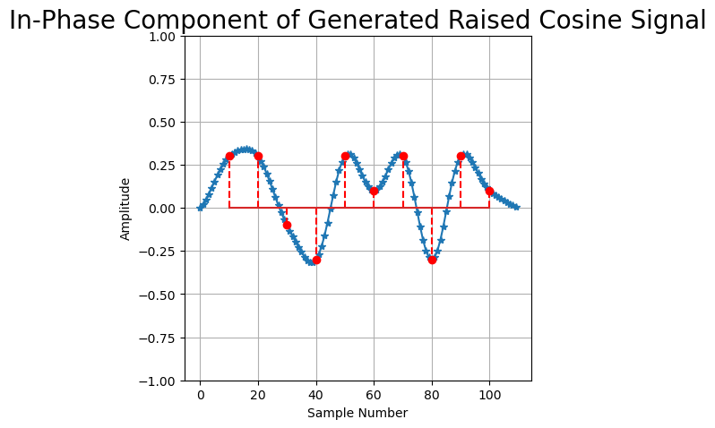

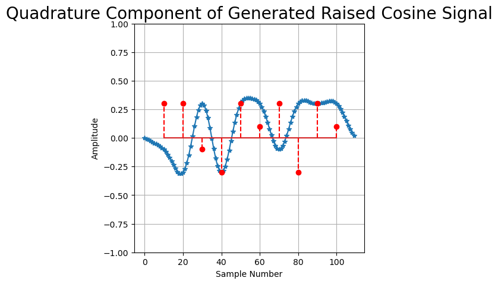

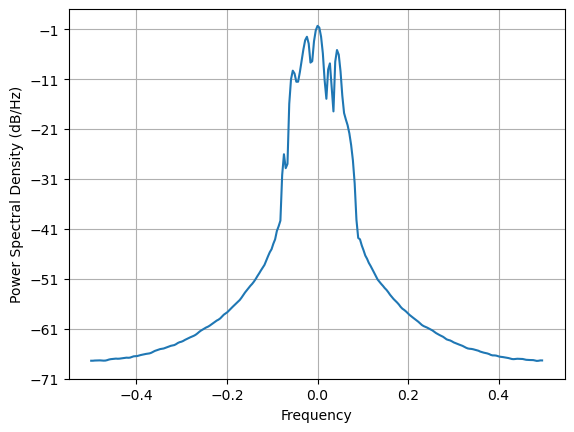

```python
####################
# LDAPM GENERATION #
####################
#
# Variables that can be changed
modulation = 'qam'
order = 16

# Generation Variables that are changed but left alone in the tutorial
samples = 10
x = 10
beta = 0.75
span = 10
totalSamples = 10

# Generate random message to send
qam_16 = modems.ldapm(sps=samples, mod_type=modulation, mod_order=order, filt_type='rc', beta=beta, span=span, trim=1)
randomSymbols = qam_16.gen_symbs(x) # Amount of total symbols

# Turn random samples into Raised Cosine Pulses
pulses = qam_16.get_samps(randomSymbols)

# Plot cosine pulses real component
plotCosinePulsesReal(pulses, samples, totalSamples)

# Plot cosine pulses imaginary component
plotCosinePulsesImaginary(pulses, samples, totalSamples)

# Plot Power Spectral Density
plotFourierTransform(pulses)
```

**Carrier Modulation**

After being modulated by the carrier frequency the signal is ready to be transmitted. This ready to transmit signal is reproduced below in the following figures.

We have reproduced a circuit diagram below to showcase the place of the carrier frequency in a generated quadrature amplitude modulated signal as a reference.

[figure not shown]

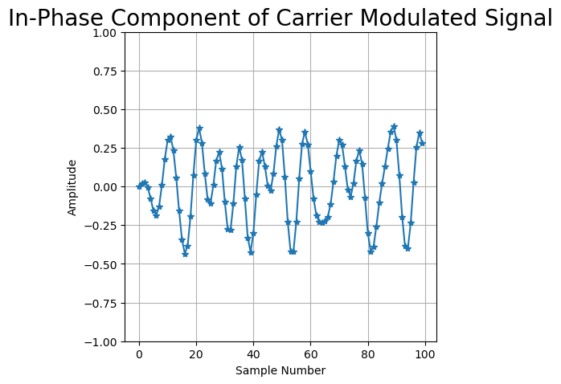

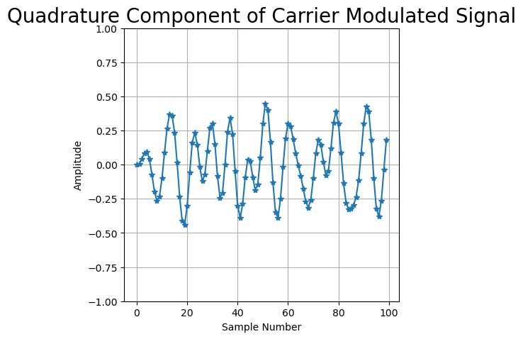

```python
# Carrier Frequency
carrierFreq = 0.1

# Modulate with the carrier signal
modulated = channels.freq_off(pulses, carrierFreq)

# Plot modulated real portion
plotCarrierModulationReal(modulated, samples, totalSamples)

# Plot modulated imaginary portion
plotCarrierModulationImaginary(modulated, samples, totalSamples)
```

**Gaussian Noise**

All signals have innate noise that occurs on the RF front end of the receiver. To simulate this, gaussian noise is added to the modulated signal utilizing the *channels.awgn* function. The *awgn* function is a Python fuction that implements an Additive White Gaussian Noise (AWGN) model - a simple noise model that is commonly used in simulating communication systems.

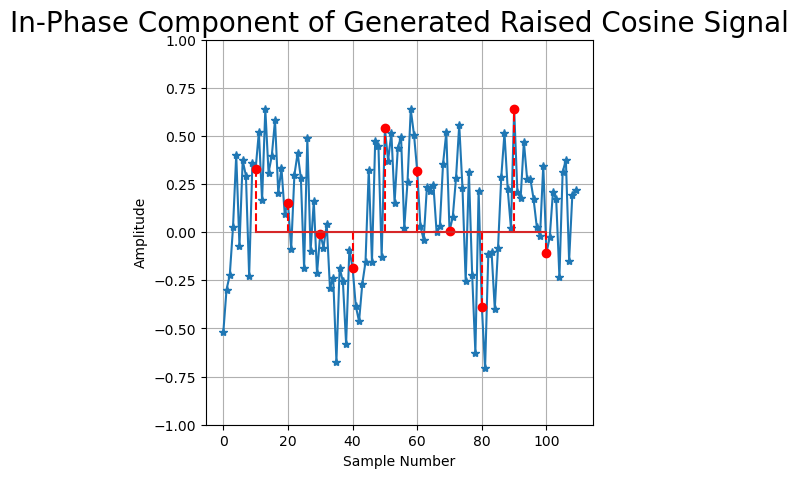

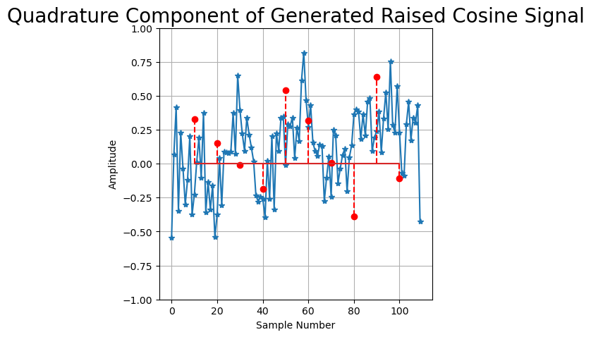

```python
# SNR ratio
snr = 10

# Adding noise
pulsesWithNoise = channels.awgn(pulses, snr, 1.0)

# Plot signals with nosie, plot real
plotCosinePulsesReal(pulsesWithNoise, samples, totalSamples)

# Plot signals with nosie, plot imaginary
plotCosinePulsesImaginary(pulsesWithNoise, samples, totalSamples)

# Get the original symbols
receiver = qam_16.get_symbs(pulsesWithNoise)
```

**Increasing Encoded Symbols**

In order for the neural network to classify and distinguish signals, for each signal we will be increasing the amount of randomly encoded symbols it transmits. By increasing the amount of randomly encoded symbols, the samples offset by the gaussian noise will cluster around a center point indexed by the quadrature symbol component and the in-phase component. This clustering can be labeled and classified - allowing the neural network the ability to distinguish between the type of modulation and the order of the modulation.

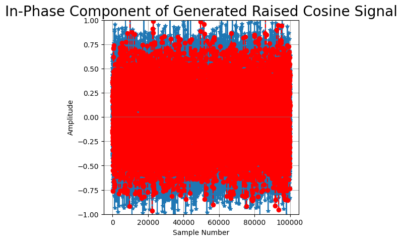

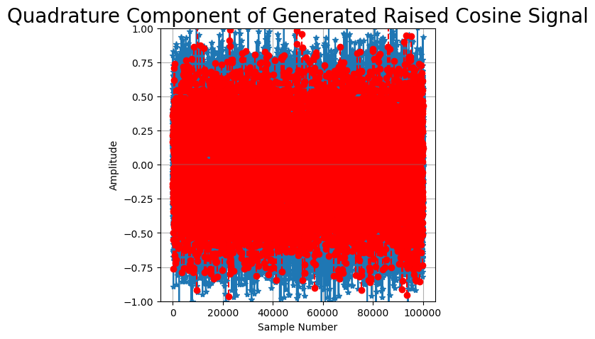

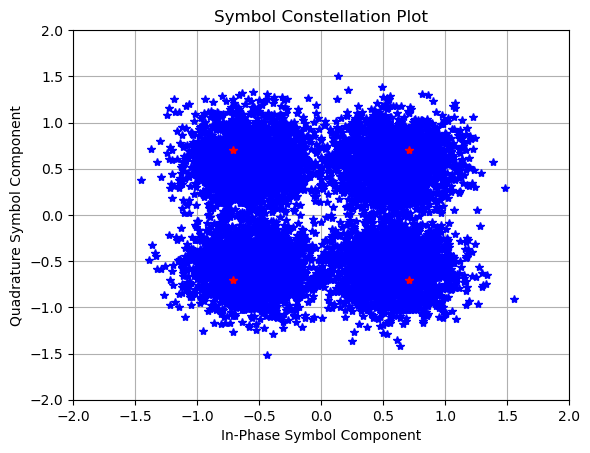

```python
# Variables
modulation = 'qam'
order = 4
samples = 10
totalSamples = 10000

# Generate random message to send
qam_16 = modems.ldapm(sps=samples, mod_type=modulation, mod_order=order, filt_type='rc', beta=beta, span=span, trim=1)
randomSymbols = qam_16.gen_symbs(totalSamples) # Amount of total symbols

# Turn random samples into Raised Cosine Pulses
pulses = qam_16.get_samps(randomSymbols)

# SNR ratio
snr = 10

# Adding noise
pulsesWithNoise = channels.awgn(pulses, snr, 1.0)

# Plot signals with nosie, plot real
plotCosinePulsesReal(pulsesWithNoise, samples, totalSamples)

# Plot signals with nosie, plot imaginary
plotCosinePulsesImaginary(pulsesWithNoise, samples, totalSamples)

# Get the original symbols
receiver = qam_16.get_symbs(pulsesWithNoise)

# Plots the demodulated signal
plotDemodulate(receiver, qam_16)
```

**Generating Training Data**

```python
def generateSignalWithNoise(modulationType, order, samples, totalSamples):

    beta = 0.75
    span = 10

    # Variables
    samples = 10
    totalSamples = 10000

    # Generate clean signal
    signal = modems.ldapm(sps=samples, mod_type=modulationType, mod_order=order, filt_type='rc', beta=beta, span=span, trim=1)

    # Generate random symbols to encode
    randomSymbols = signal.gen_symbs(totalSamples) # Amount of total symbols

    # Turn random samples into Raised Cosine Pulses
    pulses = psk_4.get_samps(randomSymbols)

    # SNR ratio
    snr = 10

    # Adding noise
    pulsesWithNoise = channels.awgn(pulses, snr, 1.0)

    return pulsesWithNoise

def generateSignalBulk(signalDict, modulationType, maxOrder, maxIteration, samples, totalSamples):

    for order in range(1, maxOrder):

        for i in range(0, maxIteration):

            key = (modulationType, order, i)

            signalDict[key] = generateSignalWithNoise(modulationType, order, samples, totalSamples)

    return signalDict

def generateAllSignals():

    # Variables
    samples = 10
    totalSamples = 10000

    # Iteration Variables
    signalDict = {}
    maxIteration = 1000

    print("START GENERATION")

    signalDict = generateSignalBulk(signalDict, 'psk', 16, maxIteration, samples, totalSamples)

    print("FINISH PSK")

    signalDict = generateSignalBulk(signalDict, 'ask', 16, maxIteration, samples, totalSamples)

    print("FINISH ASK")

    signalDict = generateSignalBulk(signalDict, 'qam', 16, maxIteration, samples, totalSamples)

    print("FINISH QAM")

    print(signalDict)

generateAllSignals()
```

```
START GENERATION
```